# RNA-seq application

## Part 4. TIDE analysis

[TIDE](http://tide.dfci.harvard.edu/) has an online version, but here we will use the offline version [TIDEpy](https://github.com/jingxinfu/TIDEpy/tree/master), which has already been installed via `pip install tidepy`.

TIDEpy is easy to use with just one commond **in the shell** (**not in R**):

```bash
tidepy /lustre1/share/rnaimmune/data/expression/VanAllen2015_CTLA4_Melanoma_RNASeq -o /path_to_your_folder/res_tide.txt -c Melanoma --force_normalize
```

You can run this commond in another terminal (remember to activate the environment), or you can exit R with saving the workspace image and run this command. For convenience, we have run this for you, and the output file is `/lustre1/share/rnaimmune/res_tide.txt`.

The results can be then analyzed using **R**.

```r
res_tide <- read.table('/lustre1/share/rnaimmune/res_tide.txt', sep='\t', header=TRUE, row.names=1)
# If you run tidepy yourself, you can load your results via
# res_tide <- read.table('/path_to_your_folder/res_tide.txt', sep='\t', header=TRUE, row.names=1)

colnames(res_tide)[2] <- 'Predicted Responder'
res_tide <- res_tide[rownames(metadata),] # reorder to be consistent with metadata
head(res_tide)

# Process the TIDE results for proper visualization
res_tide$`Predicted Responder` <- factor(res_tide$`Predicted Responder`, levels=c('False', 'True'))
levels(res_tide$`Predicted Responder`) <- c('Non-responder', 'Responder')
res_tide$CTL.flag <- factor(res_tide$CTL.flag, levels=c('False', 'True'))
levels(res_tide$CTL.flag) <- c('CTL Low', 'CTL high')
res_tide$No.benefits <- factor(res_tide$No.benefits, levels=c('False', 'True'))

res_tide <- cbind(res_tide, metadata$Response)
colnames(res_tide)[15] <- 'Responder'
```

Again, we visualize the TIDE results using heatmap.

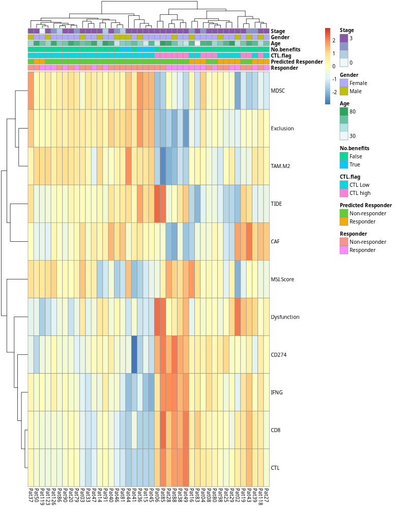

```r
# annotations for columns
annotation <- res_tide[,c(15, 2, 8, 1)]
res_tide_heatmap <- res_tide[,-c(15, 2, 8, 1)]
annotation <- cbind(annotation, metadata[,c('Age', 'Gender', 'Stage')])
head(annotation)

# heatmap plot
png('tide_heatmap.png', width=800, height=1000)
pheatmap(t(res_tide_heatmap),
         scale = 'row',
         cluster_rows = TRUE,
         cluster_cols = TRUE,
         annotation_col = annotation
)
dev.off()
```

Let's simply check the performance of TIDE prediction.

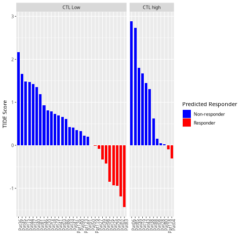

```r
# bar plot
p <- ggplot(res_tide, aes(x = reorder(rownames(res_tide), -TIDE), y = TIDE, fill = `Predicted Responder`))
p <- p + geom_bar(stat = 'identity', width = 0.7)
p <- p + scale_fill_manual(values = c('Responder' = 'red', 'Non-responder' = 'blue'))
p <- p + facet_grid(. ~ CTL.flag, space = 'free_x', scales = 'free_x')
p <- p + labs(x = '', y = 'TIDE Score')
p <- p + theme(axis.text.x = element_text(angle = 90, hjust = 1))
png('tide_predicted_responder.png')
print(p)
dev.off()
```

The prediction of responders is based on the TIDE score. If TIDE score of a patient < 0, he will be predicted as a responder, and vice versa.

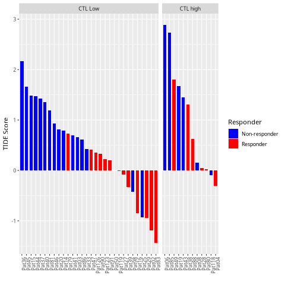

```r
# bar plot
p <- ggplot(res_tide, aes(x = reorder(rownames(res_tide), -TIDE), y = TIDE, fill = Responder))
p <- p + geom_bar(stat = 'identity', width = 0.7)
p <- p + scale_fill_manual(values = c('Responder' = 'red', 'Non-responder' = 'blue'))
p <- p + facet_grid(. ~ CTL.flag, space = 'free_x', scales = 'free_x')
p <- p + labs(x = '', y = 'TIDE Score')
p <- p + theme(axis.text.x = element_text(angle = 90, hjust = 1))
png('tide_responder.png')
print(p)
dev.off()
```

It seems that TIDE gives accurate prediction, but how to quantify it?

ROC (Receiver Operating Characteristic) curve is a graphical plot used to evaluate the performance of a binary classification model. It shows the trade-off between the **true positive rate (sensitivity)** and the **false positive rate (1-specificity)** at different threshold settings.

AUC (Area Under the Curve) refers to the area under the ROC curve. It provides a single metric to assess the model's performance. AUC values range from 0 to 1, where:

- **1** indicates a perfect model,
- **0.5** means the model is no better than random chance,
- **0** reflects a completely incorrect model.

In general, the higher the AUC, the better the model's ability to distinguish between the two classes.

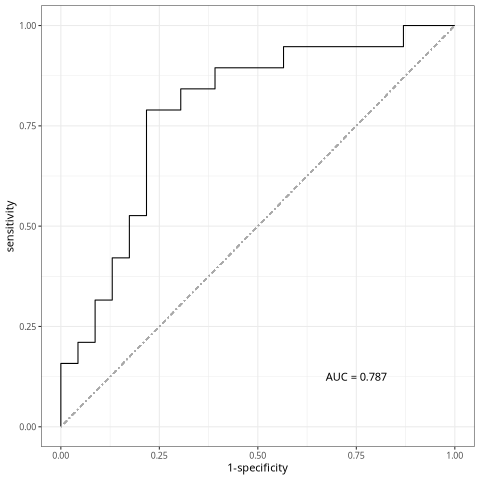

```r
library(pROC)

TIDE_roc <- roc(Responder ~ TIDE, data=res_tide, aur=TRUE)

# ROC plot
p <- ggroc(TIDE_roc, legacy.axes = TRUE)
p <- p + geom_segment(x = 0, xend = 1, y = 0, yend = 1 ,color="darkgrey", linetype=4)
p <- p + theme_bw()
p <- p + annotate("text",x=0.75,y=0.125,label = paste("AUC =", round(TIDE_roc$auc,3)))
png('roc.png')
print(p)
dev.off()
```

The ROC curve can be smoothed via a binormal smoothing.

*Note: The binormal model assumes that all variables are continuous and that there is a function that associates a score with each individual. The distribution of scores is assumed to be normal for the positive and negative populations.*

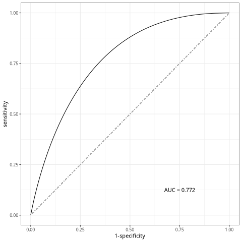

```r
# smooth the roc curve
TIDE_roc_smooth <- roc(Responder ~ TIDE, data=res_tide, aur=TRUE, smooth=TRUE)

# ROC plot
p <- ggroc(TIDE_roc_smooth, legacy.axes = TRUE)
p <- p + geom_segment(x = 0, xend = 1, y = 0, yend = 1 ,color="darkgrey", linetype=4)
p <- p + theme_bw()
p <- p + annotate("text",x=0.75,y=0.125,label = paste("AUC =", round(TIDE_roc_smooth$auc,3)))
png('roc_smooth.png')
print(p)
dev.off()
```

*Note: the AUC has been changed after smoothing.*

Finally, quit R with `q()` and type `y` to save workspace image. The next time you open R in the folder with the saved workspace image, the workspace will be reloaded automatically.